# FoodHub_Project_Okesola_Moses_Olusola

**Cost of Order vs Food Preparation Time**

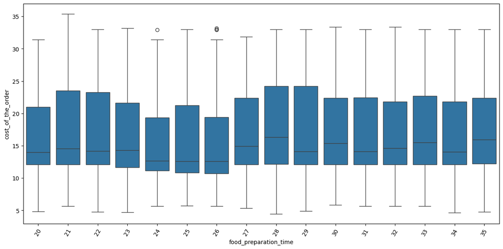

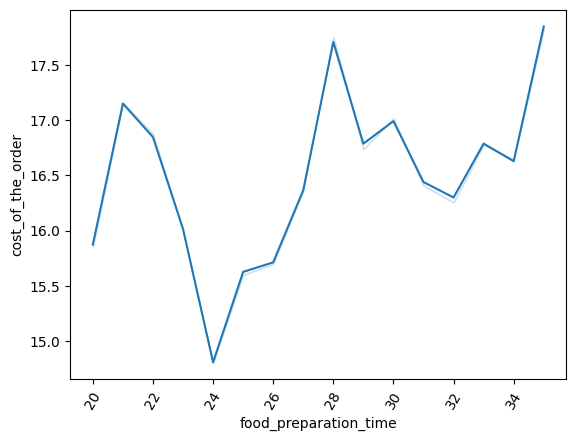

```python
# Relationship between Cost of order and Food preparation time
plt.figure(figsize=(15,7))
# visualize the relationship between Cost of order and Food preparation time using boxplot and lineplot
sns.boxplot(x="food_preparation_time", y="cost_of_the_order", data=FoodHub_data);
plt.xticks(rotation=60)
plt.show()

sns.lineplot(x="food_preparation_time",y="cost_of_the_order", data=FoodHub_data, errorbar=('ci', False));
plt.xticks(rotation=60)
plt.show()
```

- There are variations in the median for groups of costs of the order ranging from between 12 to 15 dollars, while about two or three costs of order are slightly above 15 dollars.
- There is a variation between cost of order and food preparation time.

**Cost of Order vs Delivery Time**

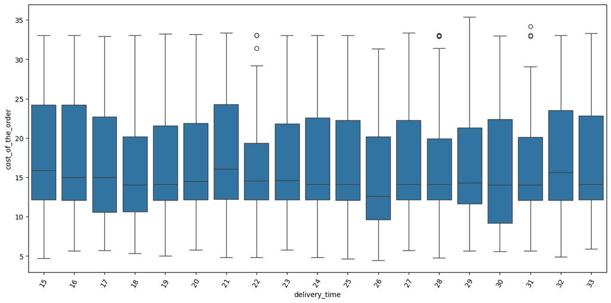

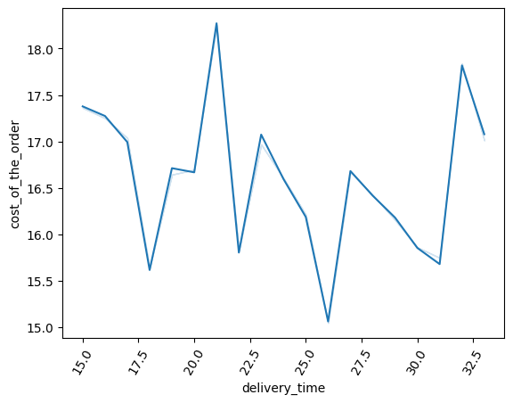

```python
# Relationship between Cost of order and Delivery time
plt.figure(figsize=(15,7))
# visualize the relationship between Cost of order and Delivery time using boxplot and lineplot
sns.boxplot(x="delivery_time", y="cost_of_the_order", data=FoodHub_data);
plt.xticks(rotation=60)
plt.show()

sns.lineplot(x="delivery_time",y="cost_of_the_order", data=FoodHub_data, errorbar=('ci', False));
plt.xticks(rotation=60)
plt.show()
```

- The median for most costs of the order is close to 15 dollars while only three costs of order are slightly above 15 dollars.
- There is a variation between cost of order and delivery time.

**Day of the Week vs Delivery Time**

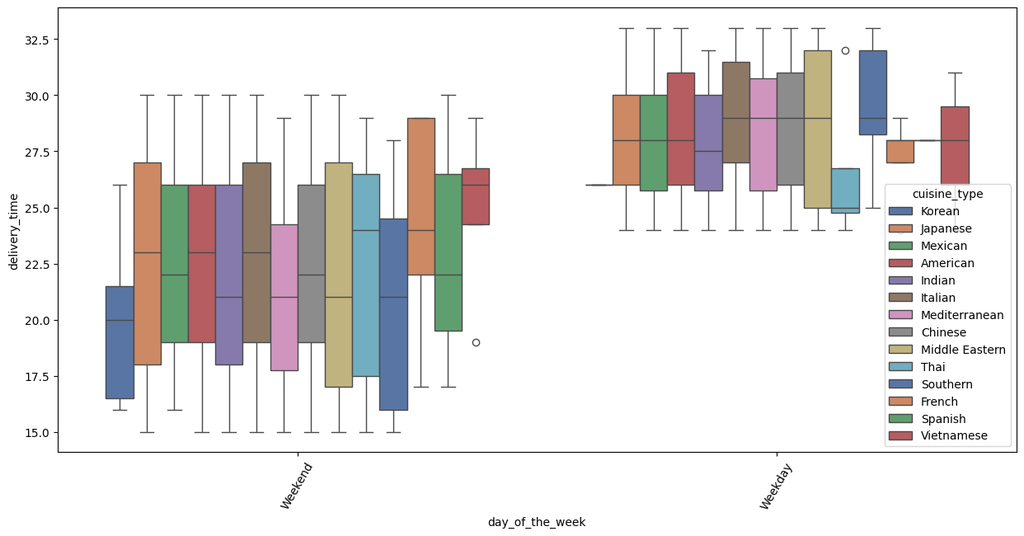

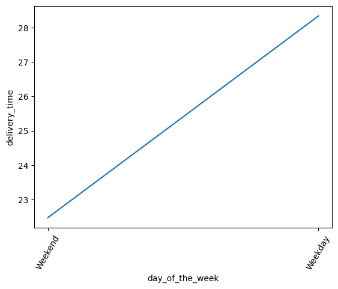

```python
# Relationship between Day of the Week and Delivery time using boxplot
plt.figure(figsize=(15,7))
# visualize the relationship between Day of the Week and Delivery time using boxplot and lineplot
sns.boxplot(x="day_of_the_week", y="delivery_time", data=FoodHub_data, hue="cuisine_type",palette='deep');
plt.xticks(rotation=60)
plt.show()

sns.lineplot(x="day_of_the_week", y="delivery_time", data=FoodHub_data, errorbar=('ci', False));
plt.xticks(rotation=60)
plt.show()
```

**Rating and Cost of the Order**

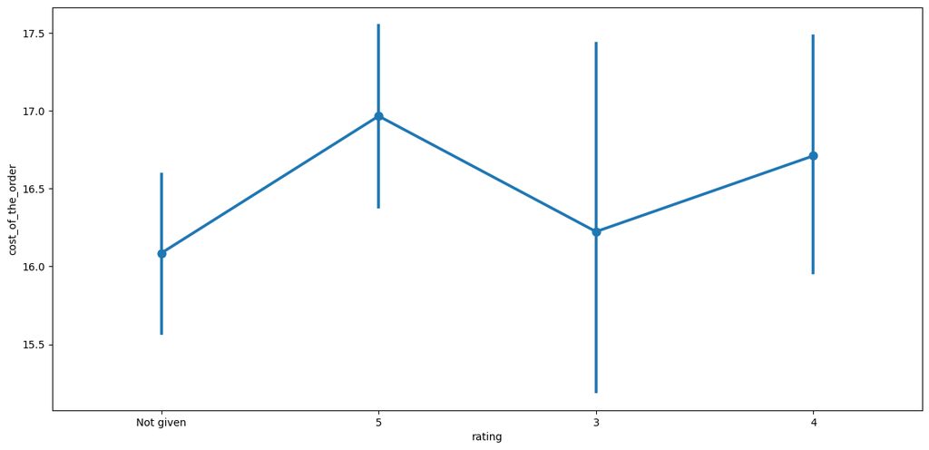

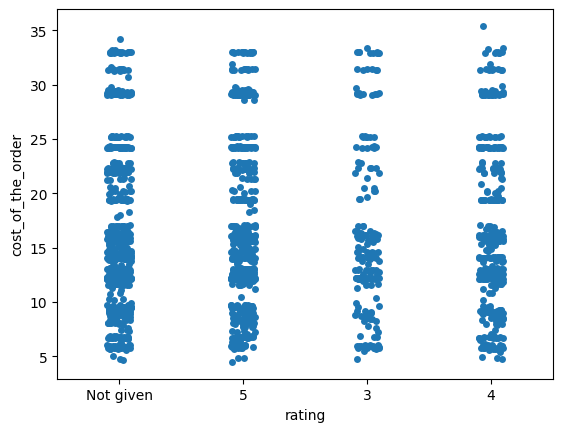

```python
# Relationship between Rating and Cost of order
plt.figure(figsize=(15,7))
# visualize the relationship between Rating and Cost of order  using pointplot and stripplot
sns.pointplot(x="rating",y="cost_of_the_order", data=FoodHub_data);
plt.show()

sns.stripplot(x = 'rating', y ="cost_of_the_order", data=FoodHub_data);
plt.show()
```

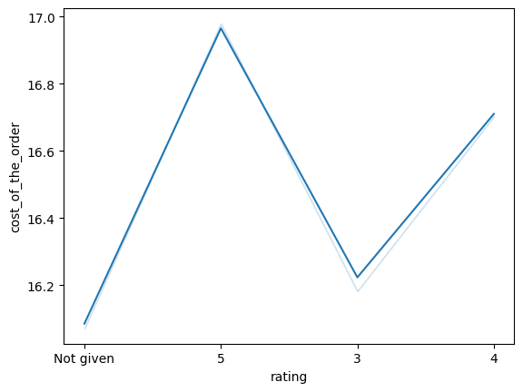

```python
sns.lineplot(x = 'rating', y ="cost_of_the_order", data=FoodHub_data, errorbar=('ci', False));
plt.show()
```

- 'Not given' rating customers spend average of 16.1 dollars to  
  order for cuisine.
- The average cost of the order by Customers who rated FooHud service 5,3,and 4 are about 17 dollars, 16.3 dollars, and 16.7 dollars respectively.
- The customers who gave 'Not given' and '5' ratings are more with food that cost 12 to about 17 dollars.
- There is more concentration of 'Not given' rating between cost of the order 12 - 17 dollars, and between 13 - 17 dollars for rating of '5'.

**Rating vs Delivery Time**

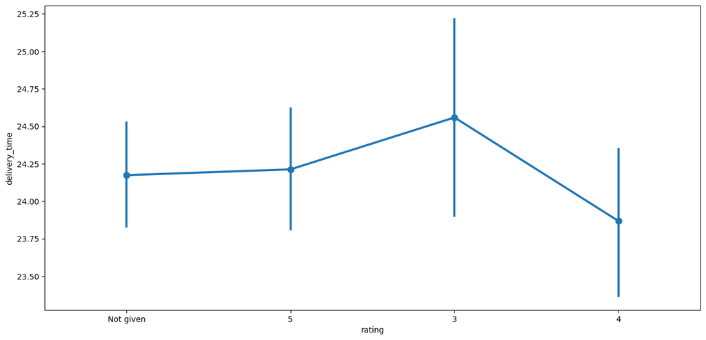

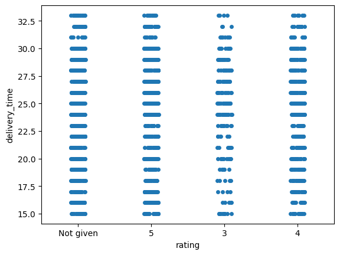

```python
# Relationship between Rating and Delivery Time
plt.figure(figsize=(15,7))
# visualize the relationship between Rating and Delivery Time  using pointplot and stripplot
sns.pointplot(x="rating",y="delivery_time", data=FoodHub_data);
plt.show()

sns.stripplot(x = 'rating', y ="delivery_time", data=FoodHub_data);
plt.show()
```

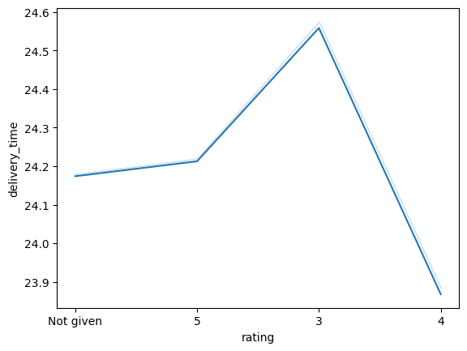

```python
sns.lineplot(x = 'rating', y ="delivery_time", data=FoodHub_data, errorbar=('ci', False));
plt.show()
```

- Customers who rated FoodHud service ' Not given" got their order at the average delivery time of 24.2 minutes.
- Customers who rated FoodHud service 5, 3, and 4 got their order at at the average delivery time of 24.22 minutes, 24.50 minutes, and 23.80 minutes respectively.
- This shows that Rating is not affected by delivery time and vice versa.

**Rating and Food Time Preparation**

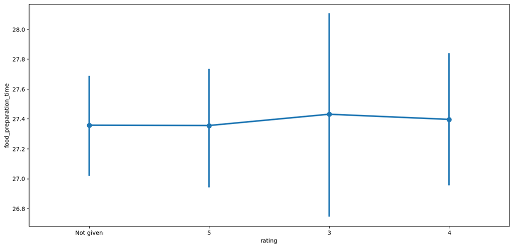

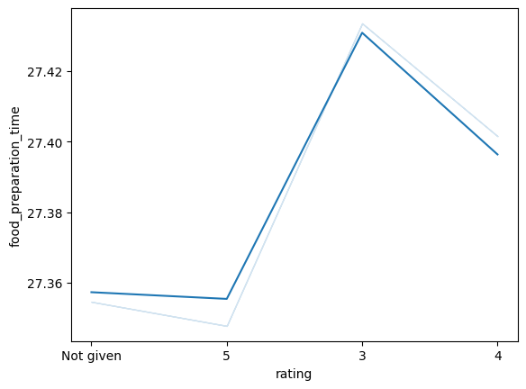

```python
# Relationship between Rating and food preparation time
plt.figure(figsize=(15,7))
# visualize the relationship between cuisine type and  cost of order using pointplot and lineplot
sns.pointplot(x="rating", y="food_preparation_time", data=FoodHub_data);
plt.show()
sns.lineplot( x="rating",y="food_preparation_time", data=FoodHub_data,errorbar=('ci', False));
plt.show()
```

**Food Preparation Time vs Delivery Time**

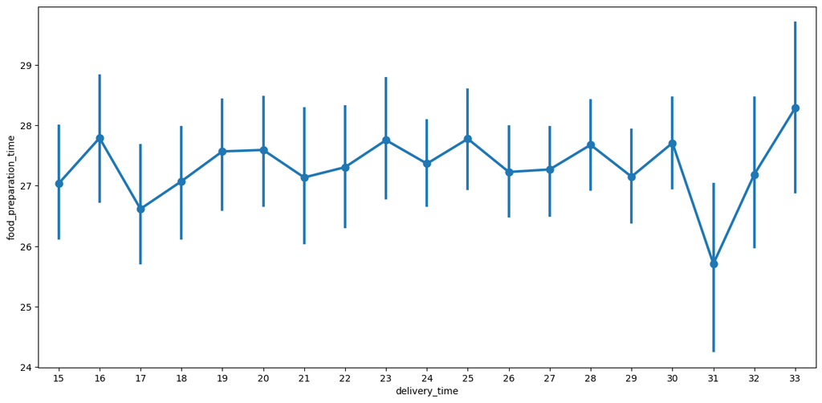

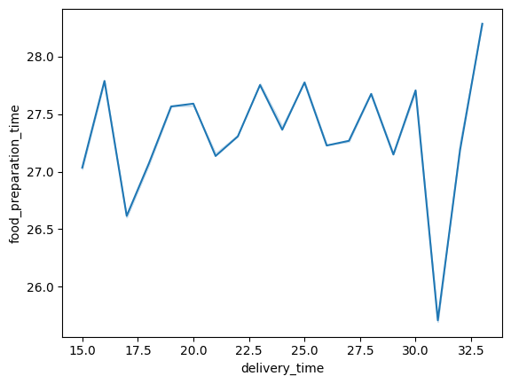

```python
# Relationship between food preparation time and delivery time
plt.figure(figsize=(15,7))
# visualize the relationship between cuisine type and  cost of order using pointplot and lineplot
sns.pointplot(x="delivery_time", y="food_preparation_time", data=FoodHub_data);
plt.show()

sns.lineplot( x="delivery_time",y="food_preparation_time", data=FoodHub_data,errorbar=('ci', False));
plt.show()
```

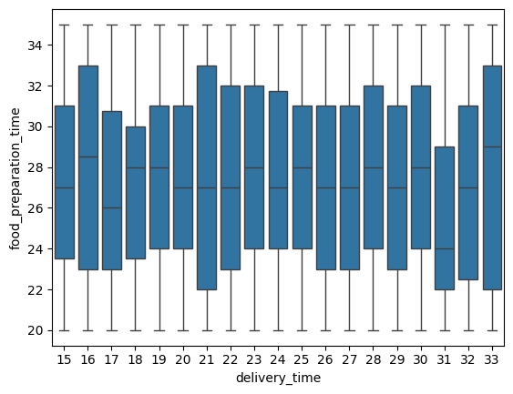

```python
sns.boxplot( x="delivery_time",y="food_preparation_time", data=FoodHub_data);
plt.show()
```

There is some variation in the food preparation time based on the delivery time but does not suggest causal relationship.

**Correlation Among variables**

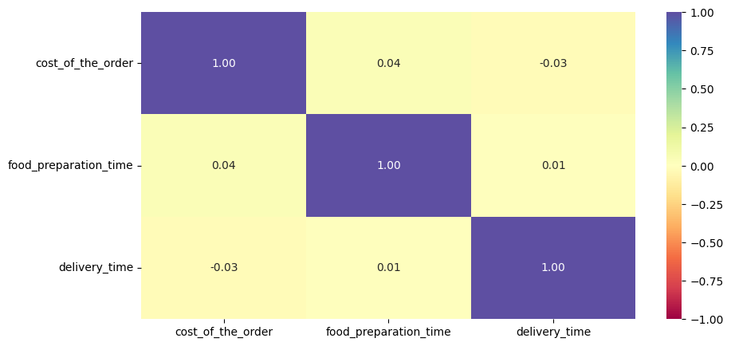

```python
# Plot the heatmap
num_var = ['cost_of_the_order', 'food_preparation_time', 'delivery_time']
plt.figure(figsize=(10, 5))
sns.heatmap(FoodHub_data[num_var].corr(), annot=True, vmin=-1, vmax=1, fmt=".2f", cbar = True, cmap="Spectral")
plt.show()
```

- There is a negative correlation (-0.03) between Cost of the order and Delivery time.
- There is a weak positive relationship (0.01) between Food preparation time and Delivery time.
- Weak positive correlation (0.04) exists between Food preparation time and cost of the order of the food.

**The company wants to provide a promotional offer in the advertisement of the restaurants. The condition to get the offer is that the restaurants must have a rating count of more than 50 and the average rating should be greater than 4. Find the restaurants fulfilling the criteria to get the promotional offer.** **(Question 13)**

```python
# Filter the rated restaurants
FoodHub_data_rated = FoodHub_data[FoodHub_data['rating'] != 'Not given'].copy()

# Convert rating column from object to integer
FoodHub_data_rated['rating'] = FoodHub_data_rated['rating'].astype('int')

# Calculate rating count by grouping the data by 'restaurant_name' and counting the ratings
FoodHub_data_rated['rating_count'] = FoodHub_data_rated.groupby('restaurant_name')['rating'].transform('count')

# Calculate average rating by grouping the data by 'restaurant_name' and calculating the mean of ratings
FoodHub_data_rated['average_rating'] = FoodHub_data_rated.groupby('restaurant_name')['rating'].transform('mean')
# Filter the restaurants based on the criteria
filtered_restaurants = FoodHub_data_rated[(FoodHub_data_rated['rating_count'] > 50) & (FoodHub_data_rated['average_rating'] > 4)]

# Print the restaurant names
print(filtered_restaurants['restaurant_name'].unique())
```

```
['Blue Ribbon Fried Chicken' 'Shake Shack' 'Blue Ribbon Sushi'
 'The Meatball Shop']
```

**The company charges the restaurant 25% on the orders having cost greater than 20 dollars and 15% on the orders having cost greater than 5 dollars. Find the net revenue generated by the company across all orders.**(**Question 14**)

```python
# Calculate the surcharges for each order
FoodHub_data['surcharge'] = 0
FoodHub_data.loc[FoodHub_data['cost_of_the_order'] > 20, 'surcharge'] = FoodHub_data['cost_of_the_order'] * 0.25
FoodHub_data.loc[(FoodHub_data['cost_of_the_order'] > 5) & (FoodHub_data['cost_of_the_order'] <= 20), 'surcharge'] = FoodHub_data['cost_of_the_order'] * 0.15

# Calculate the net revenue
Total_revenue = FoodHub_data['surcharge'].sum()

print("Total revenue generated by the company: $", Total_revenue)
```

```
Total revenue generated by the company: $ 6166.303
```

**The company wants to analyze the total time required to deliver the food. What percentage of orders take more than 60 minutes to get delivered from the time the order is placed? (The food has to be prepared and then delivered.)** (**Question 15**)

```python
# Calculate the total time required for each order (preparation time + delivery time)
FoodHub_data['total_time'] = FoodHub_data['food_preparation_time'] + FoodHub_data['delivery_time']

# Calculate the percentage of orders that take more than 60 minutes to get delivered
percentage = (FoodHub_data[FoodHub_data['total_time'] > 60].shape[0] / FoodHub_data.shape[0]) * 100

# Print the percentage
print("Percentage of orders taking more than 60 minutes for delivery:", round(percentage, 2), "%")
```

```
Percentage of orders taking more than 60 minutes for delivery: 10.54 %
```

**The company wants to analyze the delivery time of the orders on weekdays and weekends. How does the mean delivery time vary during weekdays and weekends?**( **Question 16)**

```python
# Calculate the mean delivery time for weekdays and weekends
mean_delivery_time = FoodHub_data.groupby('day_of_the_week')['delivery_time'].mean()

# Print the mean delivery time for weekdays and weekends
print(mean_delivery_time)
```

```
day_of_the_week
Weekday    28.340037
Weekend    22.470022
Name: delivery_time, dtype: float64
```

**Conclusions and Recommendations**

**Cuisine Type:**

1.American cuisine has the highest number of orders, while  
Vietnamese cuisine has the lowest. 2.The distribution of cuisine types is symmetric, with noticeable symmetry in Japanese, Mexican, American, Indian, and Italian cuisines. 3.There are a few outliers in the distribution of cuisine types.

**Cost of the Order:**

1.The cost of the order is highest at slightly above 12.1 dollars and lowest at slightly above 19.5 dollars. 2.The distribution of the cost of the order is right-skewed. The minimum cost of the order is 5 dollars, and the maximum is 35 dollars. 3.The median cost of the order is slightly above 14 dollars.

**Day of the Week:**

**Rating:**

1.'Not given' rating accounts for about 39% of the ratings and occurs most frequently. 2.Ratings 5, 4, and 3 account for about 31%, 20%, and 10% of the total ratings, respectively. 3.The rating distribution is symmetric, with the median occurring at rating 5.

**Food Preparation Time:**

**Relationships:**

1.There is a weak negative correlation (-0.03) between the cost of the order and delivery time. 2.There is a weak positive relationship (0.01) between food preparation time and delivery time. 3.There is a weak positive correlation (0.04) between food preparation time and the cost of the order.

**Based on these conclusions, the following recommendations can be made:**

1.Focus on promoting American cuisine to maintain its high number of orders.

2.Consider strategies to increase the popularity and demand for Vietnamese cuisine.

3.Monitor and manage outliers in the distribution of cuisine types.

4.Analyze the factors contributing to the higher demand for cuisine food during weekends and leverage this information for marketing and operations.

5.Pay attention to customer ratings and strive to improve the overall rating by addressing any issues or concerns. 6.Optimize food preparation time to ensure consistency and efficiency.

7.Streamline delivery processes to minimize delivery time and improve customer satisfaction.

8.Monitor the relationship between the cost of the order, food preparation time, and delivery time to identify any potential areas for improvement or cost optimization.

9.Identify the cuisine types that consistently receive high ratings across both weekends and weekdays. These popular cuisine types can be the focus of marketing efforts and menu planning.

10.Based on the analysis of ratings and customer preferences, consider offering specials or promotions for popular cuisine types during specific time slots or days. This can help attract more customers and increase sales during those periods.

11 Continuously gather feedback from customers regarding their experience with delivery time, preparation time, and the quality of different cuisine types. Use this feedback to make improvements and address any issues that arise.

12.Continuously monitor the impact of your efforts on the business metrics, such as customer satisfaction, ratings, and sales. Make adjustments as needed based on the feedback and data you collect.

13.Regularly review and update company's approach of data analysis to ensure that customer expectations are met and improving the overall food business.

**Further Area for Research**

1.Cuisine type patronage: identify if the choice of cuisine is tied to countries where customers come from. This will help in segmentation of the market to increase offering of the food prefers by a group of people.

2.There is a need to research into why 39% of customers declined to give a rating score.